# Доклад

Методы организации безопасности в операционных системах

Автор

принадлежность

Терентеевская Светлана Александровна, Student

Российский университет дружбы народов

Дата публикации

2026-03-31

# Информация

## Докладчик

- Терентеевская Светлана Александровна
- Группа НКАбд-05-25, студент бакалавра
- Российский университет дружбы народов им. П. Лумумбы
- 1032253498@rudn.ru
- https://github.com/SvetlanaTerenteevskaya

# Вводная часть

## Цели и задачи

Цель моей работы - систематизировать и проанализировать современные методы организации безопасности в ОС, выявить их сильные и слабые стороны, а также определить наиболее эффективные подходы к защите от угроз.

Для достижения этой цели необходимо решить следующие задачи:

1. Провести классификацию основных угроз безопасности операционных систем, выделив наиболее критичные типы атак.
2. Рассмотреть базовые механизмы защиты, реализуемые в современных ОС, включая идентификацию и аутентификацию, управление доступом, изоляцию процессов и аудит.
3. Изучить современные методы усиления защищённости (hardening), такие как ASLR, DEP, CFI, мандатные системы управления доступом (SELinux, AppArmor) и изоляцию на основе виртуализации.
4. Проанализировать перспективные направления развития безопасности ОС, включая концепцию Origin-Aware Security, аппаратно-программную интеграцию и применение методов искусственного интеллекта.
5. Сформулировать выводы об эффективности рассмотренных методов и дать рекомендации по их комплексному применению.

## Актуальность

Операционная система — это основа любого компьютера. Она управляет ресурсами и программами, но именно она чаще всего становится целью злоумышленников.

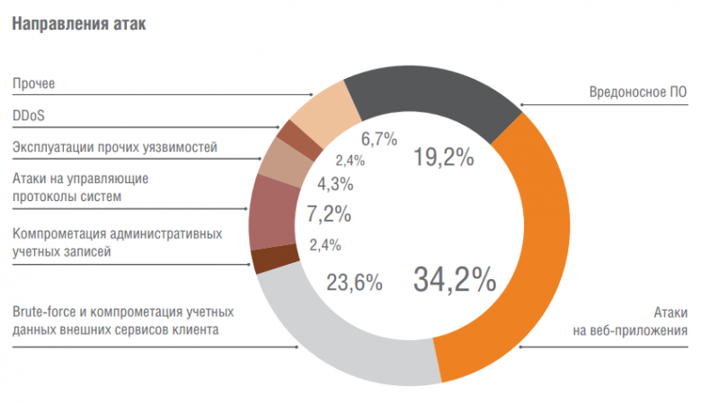

Рисунок 1: Направления атак за 2025 год

Более 20% атак направлены на веб-приложения и компрометацию учётных записей. Раньше защита сводилась к паролям и спискам доступа. Сегодня этого недостаточно. В ответ на новые угрозы разработчики создают сложные, многоуровневые системы безопасности.

# Основная часть

## Классификация угроз безопасности ОС

Угрозы безопасности классифицируются по нескольким критериям:

- По цели атаки
- По принципу воздействия на ОС
- По типу используемой злоумышленником информации
- По характеру воздействия на ОС

## Базовые механизмы безопасности

Фундамент безопасности любой ОС строится на 3 основных процессах:

- Идентификация - это процесс, в котором субъект сообщает системе, кем он является.
- Аутентификация — это процесс проверки подлинности субъекта, который перед этим прошёл идентификацию.
- Авторизация — это процесс определения прав субъекта внутри системы.

Эти процессы выполняются в определенной последовательности (рис. 2).

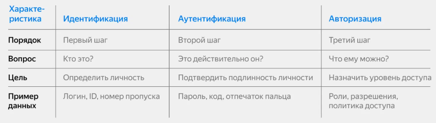

Рисунок 2: Последовательность процессов

## Модели управления доступом и изоляции

В операционных системах используются четыре основные модели управления доступом.

**Дискреционная (DAC)** — владелец ресурса сам решает, кому дать доступ. Просто, но есть риск лишних прав.

**Мандатная (MAC)** — централизованное назначение меток безопасности. Строго, но негибко. Чаще используется в госструктурах.

**Ролевая (RBAC)** — права назначаются не пользователям напрямую, а ролям. Сотрудник получает доступ в зависимости от своей роли. Это удобно для крупных организаций.

**Атрибутная (ABAC)** — доступ предоставляется на основе динамических правил. Система учитывает атрибуты: кто, к чему, когда и откуда запрашивает доступ. Это самая гибкая модель.

Важна также изоляция процессов. Операционная система не позволяет одному процессу вмешиваться в память другого. Для этого используются виртуальные машины, контейнеры и механизмы ядра.

## Современные методы усиления защиты

1. **Рандомизация адресного пространства**, или ASLR. Суть проста: программа загружается в память по случайным адресам. Злоумышленник не знает, куда именно вставить свой вредоносный код. Это эффективно против атак на переполнение буфера (рис. 3).

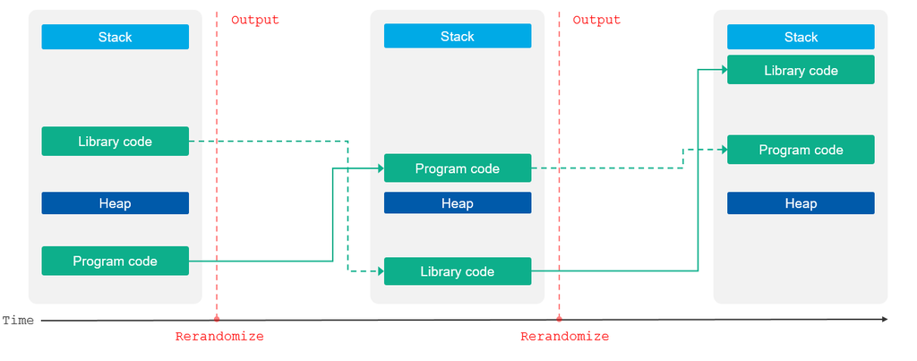

Рисунок 3: Рандомизация адресного пространства

2. **Контроль целостности потока управления**, или CFI. Он ограничивает траекторию выполнения программы только заранее определёнными путями. Если атакующий попытается перенаправить выполнение в своё вредоносное место, CFI это заблокирует.
3. **Принудительное управление доступом**. В Linux это системы SELinux и AppArmor. SELinux использует метки безопасности и очень гибок, но сложен в настройке. AppArmor проще, он работает на основе путей к файлам. Оба подхода реализуют принцип минимальных привилегий: процесс получает только те права, которые ему действительно нужны.

## Перспективные напрвления развития безопасности ОС

Что нас ждёт в будущем?

Одна из перспективных концепций — безопасность с учётом источника, или OAMAC. Современные системы не различают, откуда пришло действие: с локального входа или через удалённое подключение. Если злоумышленник взломал удалённый доступ, он получает те же права, что и локальный администратор. OAMAC предлагает различать происхождение вызова и ограничивать удалённого нарушителя даже после компрометации.

На (рис. 4) показано, как система принимает решение - разрешить действие или запретить. Но делает это только в ключевых местах ядра.

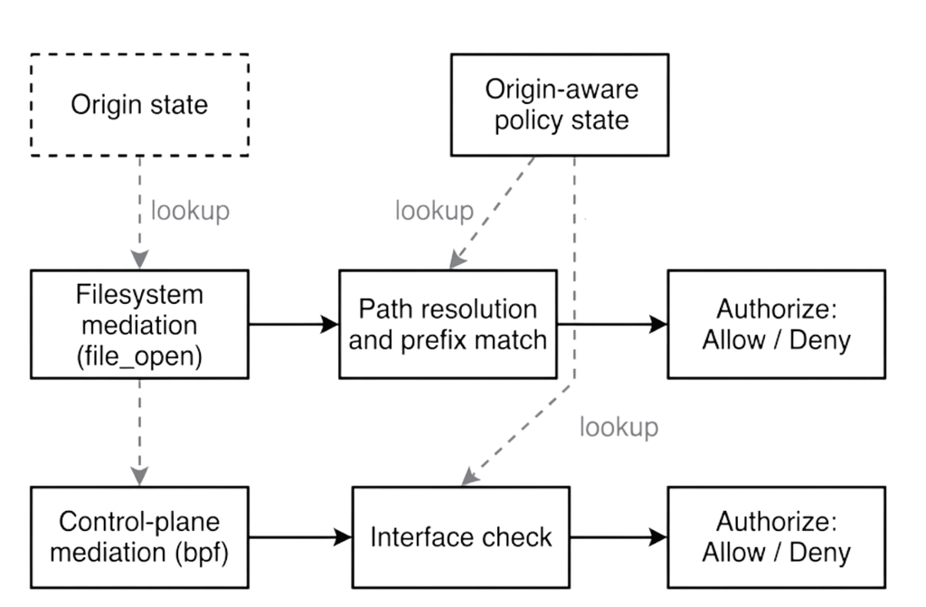

Рисунок 4: Централизованное правоприменения с учетом источника

Ещё одно направление — **искусственный интеллект**. Нейросети могут анализировать системные вызовы, предсказывать атаки и автоматически генерировать политики безопасности. Это поможет снизить нагрузку на специалистов и сделать защиту адаптивной.

## Заключение

Подводя итог, можно выделить три основных вывода:

- Безопасность ОС - это комплексная задача. Ни один метод не дает полной защиты, нужны многоуровневые решения.
- Классические механизмы остаются фундаментом, но уже недостаточны. Современнные методы - ASLR, CFI, мандатный доступ - значительно повышают устойчивость к атакам.
- Перспективы связаны с интеграцией ИИ концепций, учитывающих источник дейтсвий. Это позволит создавать более умные и адаптивные системы защиты.

# Список литературы

[Операционные системы](https://trends.rbc.ru/trends/industry/67a0b8549a794784a5330840)

[Основные угрозы безопасности](https://cyberleninka.ru/article/n/osnovnye-ugrozy-bezopasnosti-operatsionnyh-sistem/viewer)

[Анализ количества вирусов](https://tass.ru/ekonomika/22214383)

[ACLs](https://habr.com/ru/articles/154879/)

[TEE](https://learn.microsoft.com/ru-ru/azure/confidential-computing/trusted-execution-environment)

[SELinux](https://docs.redhat.com/en/documentation/Red_Hat_Enterprise_Linux/4/html/Reference_Guide/ch-selinux)

[Классификация угроз безопасности](https://studfile.net/preview/10643093/page:17/)

[Идентификация, аутентификация и авторизация](https://practicum.yandex.ru/blog/identifikatsiya-autentifikatsiya-avtorizatsiya-chem-oni-razlichayutsya/)

[Модели управления доступом](https://rt-solar.ru/products/solar_inrights/blog/3742/)

[Методы изоляции процессов](https://www.hostragons.com/ru/блог/методы-изоляции-процессов-и-песочни/#Process_Isolation_Teknikleri_Nelerdir)

[Логирование и аудит](https://ru.ruwiki.ru/wiki/Логирование_и_аудит)

[Рандомизация адресного пространства](https://www.securitylab.ru/glossary/randomizatsiya_adresnogo_prostranstva/?ref=123)

[CFI](https://ru.ruwiki.ru/wiki/Control-flow_integrity)

[MAC](https://serverspace.ru/support/glossary/mac/?utm_source=yandex.ru&utm_medium=organic&utm_campaign=yandex.ru&utm_referrer=yandex.ru)

[Виртуализация](https://blog.skillfactory.ru/glossary/virtualizatsiya/)

[Изоляция](https://learn.microsoft.com/ru-ru/azure/azure-government/azure-secure-isolation-guidance)

[OAMAC](https://arxiv.org/html/2601.14021v1)

[Применение ИИ в киберзащите](https://habr.com/ru/companies/pt/articles/904936/#1)